# Company Bankruptcy - Regression Analysis

## Loading Dataset

```r
library(DT)
df<-read.csv("C:/Users/angel/Downloads/data.csv")
X<-df[-c(1)]
y<-df[1]
datatable(head(df,50))
```

|  | Bankrupt. | ROA.C..before.interest.and.depreciation.before.interest | ROA.A..before.interest.and...after.tax | ROA.B..before.interest.and.depreciation.after.tax | Operating.Gross.Margin | Realized.Sales.Gross.Margin | Operating.Profit.Rate | Pre.tax.net.Interest.Rate | After.tax.net.Interest.Rate | Non.industry.income.and.expenditure.revenue | Continuous.interest.rate..after.tax. | Operating.Expense.Rate | Research.and.development.expense.rate | Cash.flow.rate | Interest.bearing.debt.interest.rate | Tax.rate..A. | Net.Value.Per.Share..B. | Net.Value.Per.Share..A. | Net.Value.Per.Share..C. | Persistent.EPS.in.the.Last.Four.Seasons | Cash.Flow.Per.Share | Revenue.Per.Share..Yuan.Â.. | Operating.Profit.Per.Share..Yuan.Â.. | Per.Share.Net.profit.before.tax..Yuan.Â.. | Realized.Sales.Gross.Profit.Growth.Rate | Operating.Profit.Growth.Rate | After.tax.Net.Profit.Growth.Rate | Regular.Net.Profit.Growth.Rate | Continuous.Net.Profit.Growth.Rate | … |
| --- | --- | --- | --- | --- | --- | --- | --- | --- | --- | --- | --- | --- | --- | --- | --- | --- | --- | --- | --- | --- | --- | --- | --- | --- | --- | --- | --- | --- | --- | --- |
| 1 | 1 | 0.370594257300249 | 0.424389446140427 | 0.40574977247176 | 0.601457213277793 | 0.601457213277793 | 0.998969203197885 | 0.796887145860514 | 0.808809360876843 | 0.302646433889668 | 0.780984850207341 | 0.000125696868875964 | 0 | 0.458143143520965 | 0.000725072507250725 | 0 | 0.147949938898487 | 0.147949938898487 | 0.147949938898487 | 0.16914058806845 | 0.311664426681757 | 0.0175597803893099 | 0.0959205276443286 | 0.138736160277171 | 0.0221022783580128 | 0.848194994526472 | 0.688979462807371 | 0.688979462807371 | 0.217535386199635 | … |
| 2 | 1 | 0.464290937454297 | 0.53821412996075 | 0.516730017666899 | 0.610235085544617 | 0.610235085544617 | 0.998945978205482 | 0.797380191277827 | 0.809300725667939 | 0.303556430290771 | 0.781505974330882 | 0.000289785053728762 | 0 | 0.461867257156757 | 0.000647064706470647 | 0 | 0.182251064009102 | 0.182251064009102 | 0.182251064009102 | 0.2089439349532 | 0.318136804131004 | 0.0211443350424248 | 0.0937220096083381 | 0.16991790314077 | 0.0220801698690499 | 0.848087883815147 | 0.689692901209989 | 0.689701701610895 | 0.217619596450422 | … |
| 3 | 1 | 0.426071271876371 | 0.499018752725687 | 0.472295090743616 | 0.601450006486113 | 0.601363524985947 | 0.998857353483229 | 0.796403369254357 | 0.808387521469543 | 0.302035177342951 | 0.780283936155909 | 0.000236129720556318 | 25500000 | 0.458520587470538 | 0.00079007900790079 | 0 | 0.177910749652353 | 0.177910749652353 | 0.193712865028865 | 0.180580504869056 | 0.30710193110278 | 0.00594400834883616 | 0.0923377575116033 | 0.142803344128945 | 0.0227600967722855 | 0.84809401283004 | 0.689462676951537 | 0.689469659564714 | 0.217601298963609 | … |
| 4 | 1 | 0.399844001364988 | 0.451264718709115 | 0.457733283366347 | 0.583541129160121 | 0.583541129160121 | 0.998699747067122 | 0.796966968308828 | 0.808965597694361 | 0.303349536022685 | 0.781240991205311 | 0.00010788884881442 | 0 | 0.465705442741753 | 0.000449044904490449 | 0 | 0.154186507100417 | 0.154186507100417 | 0.154186507100417 | 0.193722227474709 | 0.321673622409281 | 0.0143684680188151 | 0.0777623971989252 | 0.148602847028696 | 0.0220460668531945 | 0.8480054773865 | 0.689109535618137 | 0.689109535618137 | 0.217568188277463 | … |
| 5 | 1 | 0.465022181055916 | 0.538432184910597 | 0.522297767546443 | 0.598783493564335 | 0.598783493564335 | 0.998973131803565 | 0.797366080550396 | 0.809303720206941 | 0.303474977757658 | 0.781550044617657 | 7890000000 | 0 | 0.462746282177097 | 0.000686068606860686 | 0 | 0.167502422991024 | 0.167502422991024 | 0.167502422991024 | 0.212536636097192 | 0.319162481431704 | 0.0296897923378254 | 0.0968976467714356 | 0.168411538751224 | 0.0220959097225217 | 0.848258202198295 | 0.689696883030727 | 0.689696883030727 | 0.217625639200419 | … |
| 6 | 1 | 0.388680349046946 | 0.415176624509376 | 0.419133786605279 | 0.590171377506162 | 0.590250652214647 | 0.998758098416194 | 0.796903193354456 | 0.808770562067159 | 0.303115813175443 | 0.7810690609464 | 0.000157149995218431 | 0 | 0.465861452907577 | 0.000716071607160716 | 0 | 0.15557709325355 | 0.15557709325355 | 0.15557709325355 | 0.174435095017491 | 0.325387281601471 | 0.0181042697037071 | 0.0780881035746275 | 0.138811478496648 | 0.0215649425169015 | 0.847982831794045 | 0.689105149844571 | 0.689177543962186 | 0.21756642290514 | … |
| 7 | 0 | 0.390922829425243 | 0.445704317488007 | 0.436158252583115 | 0.619949840729904 | 0.619949840729904 | 0.998993121473643 | 0.797011928959958 | 0.808960389800444 | 0.302814414633032 | 0.781180078770725 | 0.000398483358000525 | 730000000 | 0.461020105181047 | 0.000805080508050805 | 0 | 0.158821794277527 | 0.158821794277527 | 0.158821794277527 | 0.161482461945731 | 0.31668670863691 | 0.0309148932952191 | 0.0999104307466819 | 0.128944791745123 | 0.0221122500924914 | 0.84832246862509 | 0.688589850304315 | 0.688589850304315 | 0.217604461369292 | … |
| 8 | 0 | 0.508360551845171 | 0.570922372437854 | 0.559077038385353 | 0.601738278153332 | 0.60171665777829 | 0.999008951443589 | 0.797448808148475 | 0.809361527829423 | 0.303544587044117 | 0.781621483394625 | 9000000000 | 50900000 | 0.467023980272263 | 0.00063006300630063 | 0.157607045247495 | 0.176983692216931 | 0.176983692216931 | 0.176983692216931 | 0.22520563486811 | 0.324114027021292 | 0.0425609147420482 | 0.104796026382216 | 0.180462453867591 | 0.0221143202941026 | 0.848082154774354 | 0.689535186484246 | 0.689535186484246 | 0.217633191808323 | … |
| 9 | 0 | 0.48851947545459 | 0.545137374618404 | 0.5432839017078 | 0.603612043990256 | 0.603612043990256 | 0.998960768250395 | 0.797413531329896 | 0.809338092306795 | 0.303583500568838 | 0.781598185090152 | 0.000168713644609044 | 0 | 0.463142178941983 | 0.000737073707370737 | 0.00587103957890475 | 0.184189456828621 | 0.184189456828621 | 0.184189456828621 | 0.218398411647915 | 0.318773431421094 | 0.0266043528895745 | 0.0951876882989984 | 0.173156586578293 | 0.0221284324318037 | 0.848158761578544 | 0.689924337326926 | 0.689924337326926 | 0.217653752422812 | … |
| 10 | 0 | 0.495685662750451 | 0.550915830789359 | 0.542962685368596 | 0.599208694273483 | 0.599208694273483 | 0.999000632043326 | 0.797403570816415 | 0.809320385467476 | 0.303482953821731 | 0.78157418502952 | 5820000000 | 0 | 0.470575308455583 | 0.000672067206720672 | 0.392448628403685 | 0.177447220934642 | 0.177447220934642 | 0.177447220934642 | 0.217831143046232 | 0.330161986277145 | 0.0786635812272184 | 0.109844475205602 | 0.176621224674249 | 0.0221183026666678 | 0.84808350762793 | 0.689338461456783 | 0.689338461456783 | 0.217700368870897 | … |

[output cut: 40 more lines]

Y - Bankrupt?: Class label  
X1 - ROA(C) before interest and depreciation before interest: Return On Total Assets(C)  
X2 - ROA(A) before interest and % after tax: Return On Total Assets(A)  
X3 - ROA(B) before interest and depreciation after tax: Return On Total Assets(B)  
X4 - Operating Gross Margin: Gross Profit/Net Sales  
X5 - Realized Sales Gross Margin: Realized Gross Profit/Net Sales  
X6 - Operating Profit Rate: Operating Income/Net Sales  
X7 - Pre-tax net Interest Rate: Pre-Tax Income/Net Sales  
X8 - After-tax net Interest Rate: Net Income/Net Sales  
X9 - Non-industry income and expenditure/revenue: Net Non-operating Income Ratio  
X10 - Continuous interest rate (after tax): Net Income-Exclude Disposal Gain or Loss/Net Sales  
X11 - Operating Expense Rate: Operating Expenses/Net Sales  
X12 - Research and development expense rate: (Research and Development Expenses)/Net Sales  
X13 - Cash flow rate: Cash Flow from Operating/Current Liabilities  
X14 - Interest-bearing debt interest rate: Interest-bearing Debt/Equity  
X15 - Tax rate (A): Effective Tax Rate  
X16 - Net Value Per Share (B): Book Value Per Share(B)  
X17 - Net Value Per Share (A): Book Value Per Share(A)  
X18 - Net Value Per Share (C): Book Value Per Share(C)  
X19 - Persistent EPS in the Last Four Seasons: EPS-Net Income  
X20 - Cash Flow Per Share  
X21 - Revenue Per Share (Yuan ¥): Sales Per Share  
X22 - Operating Profit Per Share (Yuan ¥): Operating Income Per Share  
X23 - Per Share Net profit before tax (Yuan ¥): Pretax Income Per Share  
X24 - Realized Sales Gross Profit Growth Rate  
X25 - Operating Profit Growth Rate: Operating Income Growth  
X26 - After-tax Net Profit Growth Rate: Net Income Growth  
X27 - Regular Net Profit Growth Rate: Continuing Operating Income after Tax Growth  
X28 - Continuous Net Profit Growth Rate: Net Income-Excluding Disposal Gain or Loss Growth  
X29 - Total Asset Growth Rate: Total Asset Growth  
X30 - Net Value Growth Rate: Total Equity Growth  
X31 - Total Asset Return Growth Rate Ratio: Return on Total Asset Growth  
X32 - Cash Reinvestment %: Cash Reinvestment Ratio  
X33 - Current Ratio  
X34 - Quick Ratio: Acid Test  
X35 - Interest Expense Ratio: Interest Expenses/Total Revenue  
X36 - Total debt/Total net worth: Total Liability/Equity Ratio  
X37 - Debt ratio %: Liability/Total Assets  
X38 - Net worth/Assets: Equity/Total Assets  
X39 - Long-term fund suitability ratio (A): (Long-term Liability+Equity)/Fixed Assets  
X40 - Borrowing dependency: Cost of Interest-bearing Debt  
X41 - Contingent liabilities/Net worth: Contingent Liability/Equity  
X42 - Operating profit/Paid-in capital: Operating Income/Capital  
X43 - Net profit before tax/Paid-in capital: Pretax Income/Capital  
X44 - Inventory and accounts receivable/Net value: (Inventory+Accounts Receivables)/Equity  
X45 - Total Asset Turnover  
X46 - Accounts Receivable Turnover  
X47 - Average Collection Days: Days Receivable Outstanding  
X48 - Inventory Turnover Rate (times)  
X49 - Fixed Assets Turnover Frequency  
X50 - Net Worth Turnover Rate (times): Equity Turnover  
X51 - Revenue per person: Sales Per Employee  
X52 - Operating profit per person: Operation Income Per Employee  
X53 - Allocation rate per person: Fixed Assets Per Employee  
X54 - Working Capital to Total Assets  
X55 - Quick Assets/Total Assets  
X56 - Current Assets/Total Assets  
X57 - Cash/Total Assets  
X58 - Quick Assets/Current Liability  
X59 - Cash/Current Liability  
X60 - Current Liability to Assets  
X61 - Operating Funds to Liability  
X62 - Inventory/Working Capital  
X63 - Inventory/Current Liability  
X64 - Current Liabilities/Liability  
X65 - Working Capital/Equity  
X66 - Current Liabilities/Equity  
X67 - Long-term Liability to Current Assets  
X68 - Retained Earnings to Total Assets  
X69 - Total income/Total expense  
X70 - Total expense/Assets  
X71 - Current Asset Turnover Rate: Current Assets to Sales  
X72 - Quick Asset Turnover Rate: Quick Assets to Sales  
X73 - Working capitcal Turnover Rate: Working Capital to Sales  
X74 - Cash Turnover Rate: Cash to Sales  
X75 - Cash Flow to Sales  
X76 - Fixed Assets to Assets  
X77 - Current Liability to Liability  
X78 - Current Liability to Equity  
X79 - Equity to Long-term Liability  
X80 - Cash Flow to Total Assets  
X81 - Cash Flow to Liability  
X82 - CFO to Assets  
X83 - Cash Flow to Equity  
X84 - Current Liability to Current Assets  
X85 - Liability-Assets Flag: 1 if Total Liability exceeds Total Assets, 0 otherwise  
X86 - Net Income to Total Assets  
X87 - Total assets to GNP price  
X88 - No-credit Interval  
X89 - Gross Profit to Sales  
X90 - Net Income to Stockholder’s Equity  
X91 - Liability to Equity  
X92 - Degree of Financial Leverage (DFL)  
X93 - Interest Coverage Ratio (Interest expense to EBIT)  
X94 - Net Income Flag: 1 if Net Income is Negative for the last two years, 0 otherwise  
X95 - Equity to Liability

## Summary for each variable

```r
library(skimr)
skim(df)
```

Data summary

| Name | df |
| --- | --- |
| Number of rows | 6819 |
| Number of columns | 96 |
| _______________________ |  |
| Column type frequency: |  |
| numeric | 96 |
| ________________________ |  |
| Group variables | None |

**Variable type: numeric**

| skim_variable | n_missing | complete_rate | mean | sd | p0 | p25 | p50 | p75 | p100 | hist |
| --- | --- | --- | --- | --- | --- | --- | --- | --- | --- | --- |
| Bankrupt. | 0 | 1 | 3.000000e-02 | 1.800000e-01 | 0 | 0.00e+00 | 0.00e+00 | 0.000e+00 | 1.00e+00 | ▇▁▁▁▁ |
| ROA.C..before.interest.and.depreciation.before.interest | 0 | 1 | 5.100000e-01 | 6.000000e-02 | 0 | 4.80e-01 | 5.00e-01 | 5.400e-01 | 1.00e+00 | ▁▁▇▁▁ |
| ROA.A..before.interest.and…after.tax | 0 | 1 | 5.600000e-01 | 7.000000e-02 | 0 | 5.40e-01 | 5.60e-01 | 5.900e-01 | 1.00e+00 | ▁▁▇▂▁ |
| ROA.B..before.interest.and.depreciation.after.tax | 0 | 1 | 5.500000e-01 | 6.000000e-02 | 0 | 5.30e-01 | 5.50e-01 | 5.800e-01 | 1.00e+00 | ▁▁▇▂▁ |
| Operating.Gross.Margin | 0 | 1 | 6.100000e-01 | 2.000000e-02 | 0 | 6.00e-01 | 6.10e-01 | 6.100e-01 | 1.00e+00 | ▁▁▂▇▁ |
| Realized.Sales.Gross.Margin | 0 | 1 | 6.100000e-01 | 2.000000e-02 | 0 | 6.00e-01 | 6.10e-01 | 6.100e-01 | 1.00e+00 | ▁▁▂▇▁ |
| Operating.Profit.Rate | 0 | 1 | 1.000000e+00 | 1.000000e-02 | 0 | 1.00e+00 | 1.00e+00 | 1.000e+00 | 1.00e+00 | ▁▁▁▁▇ |
| Pre.tax.net.Interest.Rate | 0 | 1 | 8.000000e-01 | 1.000000e-02 | 0 | 8.00e-01 | 8.00e-01 | 8.000e-01 | 1.00e+00 | ▁▁▁▇▁ |
| After.tax.net.Interest.Rate | 0 | 1 | 8.100000e-01 | 1.000000e-02 | 0 | 8.10e-01 | 8.10e-01 | 8.100e-01 | 1.00e+00 | ▁▁▁▁▇ |
| Non.industry.income.and.expenditure.revenue | 0 | 1 | 3.000000e-01 | 1.000000e-02 | 0 | 3.00e-01 | 3.00e-01 | 3.000e-01 | 1.00e+00 | ▁▇▁▁▁ |
| Continuous.interest.rate..after.tax. | 0 | 1 | 7.800000e-01 | 1.000000e-02 | 0 | 7.80e-01 | 7.80e-01 | 7.800e-01 | 1.00e+00 | ▁▁▁▇▁ |
| Operating.Expense.Rate | 0 | 1 | 1.995347e+09 | 3.237684e+09 | 0 | 0.00e+00 | 0.00e+00 | 4.145e+09 | 9.99e+09 | ▇▁▁▁▁ |
| Research.and.development.expense.rate | 0 | 1 | 1.950427e+09 | 2.598292e+09 | 0 | 0.00e+00 | 5.09e+08 | 3.450e+09 | 9.98e+09 | ▇▂▁▁▁ |
| Cash.flow.rate | 0 | 1 | 4.700000e-01 | 2.000000e-02 | 0 | 4.60e-01 | 4.70e-01 | 4.700e-01 | 1.00e+00 | ▁▁▇▁▁ |
| Interest.bearing.debt.interest.rate | 0 | 1 | 1.644801e+07 | 1.082750e+08 | 0 | 0.00e+00 | 0.00e+00 | 0.000e+00 | 9.90e+08 | ▇▁▁▁▁ |
| Tax.rate..A. | 0 | 1 | 1.200000e-01 | 1.400000e-01 | 0 | 0.00e+00 | 7.00e-02 | 2.100e-01 | 1.00e+00 | ▇▂▁▁▁ |
| Net.Value.Per.Share..B. | 0 | 1 | 1.900000e-01 | 3.000000e-02 | 0 | 1.70e-01 | 1.80e-01 | 2.000e-01 | 1.00e+00 | ▇▂▁▁▁ |
| Net.Value.Per.Share..A. | 0 | 1 | 1.900000e-01 | 3.000000e-02 | 0 | 1.70e-01 | 1.80e-01 | 2.000e-01 | 1.00e+00 | ▇▂▁▁▁ |
| Net.Value.Per.Share..C. | 0 | 1 | 1.900000e-01 | 3.000000e-02 | 0 | 1.70e-01 | 1.80e-01 | 2.000e-01 | 1.00e+00 | ▇▂▁▁▁ |
| Persistent.EPS.in.the.Last.Four.Seasons | 0 | 1 | 2.300000e-01 | 3.000000e-02 | 0 | 2.10e-01 | 2.20e-01 | 2.400e-01 | 1.00e+00 | ▁▇▁▁▁ |
| Cash.Flow.Per.Share | 0 | 1 | 3.200000e-01 | 2.000000e-02 | 0 | 3.20e-01 | 3.20e-01 | 3.300e-01 | 1.00e+00 | ▁▇▁▁▁ |
| Revenue.Per.Share..Yuan.Â.. | 0 | 1 | 1.328641e+06 | 5.170709e+07 | 0 | 2.00e-02 | 3.00e-02 | 5.000e-02 | 3.02e+09 | ▇▁▁▁▁ |
| Operating.Profit.Per.Share..Yuan.Â.. | 0 | 1 | 1.100000e-01 | 3.000000e-02 | 0 | 1.00e-01 | 1.00e-01 | 1.200e-01 | 1.00e+00 | ▇▁▁▁▁ |
| Per.Share.Net.profit.before.tax..Yuan.Â.. | 0 | 1 | 1.800000e-01 | 3.000000e-02 | 0 | 1.70e-01 | 1.80e-01 | 1.900e-01 | 1.00e+00 | ▇▂▁▁▁ |
| Realized.Sales.Gross.Profit.Growth.Rate | 0 | 1 | 2.000000e-02 | 1.000000e-02 | 0 | 2.00e-02 | 2.00e-02 | 2.000e-02 | 1.00e+00 | ▇▁▁▁▁ |
| Operating.Profit.Growth.Rate | 0 | 1 | 8.500000e-01 | 1.000000e-02 | 0 | 8.50e-01 | 8.50e-01 | 8.500e-01 | 1.00e+00 | ▁▁▁▁▇ |
| After.tax.Net.Profit.Growth.Rate | 0 | 1 | 6.900000e-01 | 1.000000e-02 | 0 | 6.90e-01 | 6.90e-01 | 6.900e-01 | 1.00e+00 | ▁▁▁▇▁ |
| Regular.Net.Profit.Growth.Rate | 0 | 1 | 6.900000e-01 | 1.000000e-02 | 0 | 6.90e-01 | 6.90e-01 | 6.900e-01 | 1.00e+00 | ▁▁▁▇▁ |
| Continuous.Net.Profit.Growth.Rate | 0 | 1 | 2.200000e-01 | 1.000000e-02 | 0 | 2.20e-01 | 2.20e-01 | 2.200e-01 | 1.00e+00 | ▁▇▁▁▁ |
| Total.Asset.Growth.Rate | 0 | 1 | 5.508097e+09 | 2.897718e+09 | 0 | 4.86e+09 | 6.40e+09 | 7.390e+09 | 9.99e+09 | ▃▁▃▇▂ |

[output cut: 66 more lines]

## Correlation among variables

In order to fit linear regression, we need some appropriate correlation among variables

```r
corr_matrix <- round(cor(df[-c(1)]), 2) #drop the target column
which(abs(corr_matrix) > 0.95 & corr_matrix < 1, arr.ind=TRUE)
```

```
##                                                         row col
## ROA.B..before.interest.and.depreciation.after.tax         3   1
## ROA.B..before.interest.and.depreciation.after.tax         3   2
## Net.Income.to.Total.Assets                               86   2
## ROA.C..before.interest.and.depreciation.before.interest   1   3
## ROA.A..before.interest.and...after.tax                    2   3
## After.tax.net.Interest.Rate                               8   7
## Continuous.interest.rate..after.tax.                     10   7
## Pre.tax.net.Interest.Rate                                 7   8
## Continuous.interest.rate..after.tax.                     10   8
## Pre.tax.net.Interest.Rate                                 7  10
## After.tax.net.Interest.Rate                               8  10
## Per.Share.Net.profit.before.tax..Yuan.Â..                23  19
## Net.profit.before.tax.Paid.in.capital                    43  19
## Persistent.EPS.in.the.Last.Four.Seasons                  19  23
## Net.profit.before.tax.Paid.in.capital                    43  23
## Net.worth.Assets                                         38  37
## Debt.ratio..                                             37  38
## Liability.to.Equity                                      91  40
## Persistent.EPS.in.the.Last.Four.Seasons                  19  43
## Per.Share.Net.profit.before.tax..Yuan.Â..                23  43
## Liability.to.Equity                                      91  66
## Liability.to.Equity                                      91  78
## ROA.A..before.interest.and...after.tax                    2  86
## Borrowing.dependency                                     40  91
## Current.Liabilities.Equity                               66  91
## Current.Liability.to.Equity                              78  91
```

## Linear Regression with one predictor

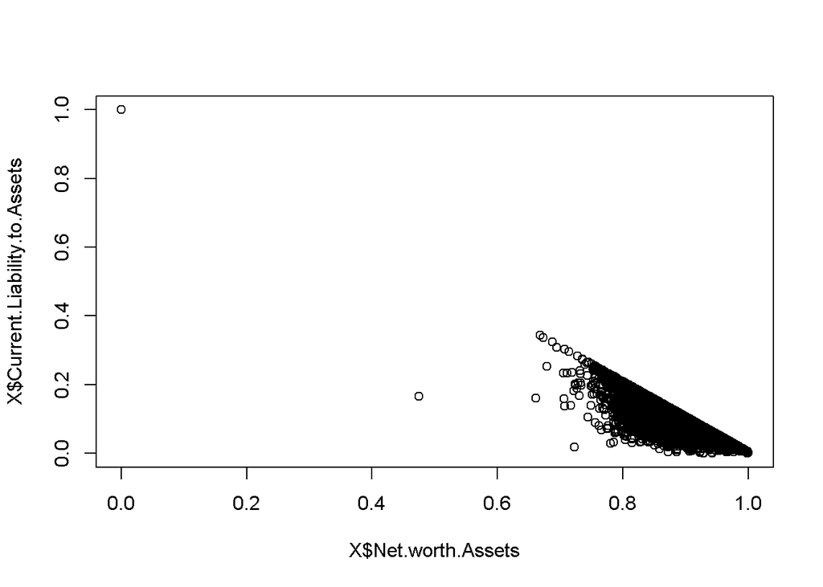

```r
plot(X$Net.worth.Assets, X$Current.Liability.to.Assets)
```

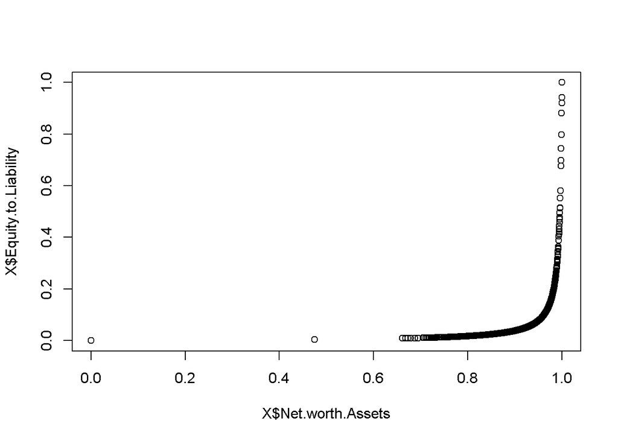

```r
plot(X$Net.worth.Assets, X$Equity.to.Liability)
```

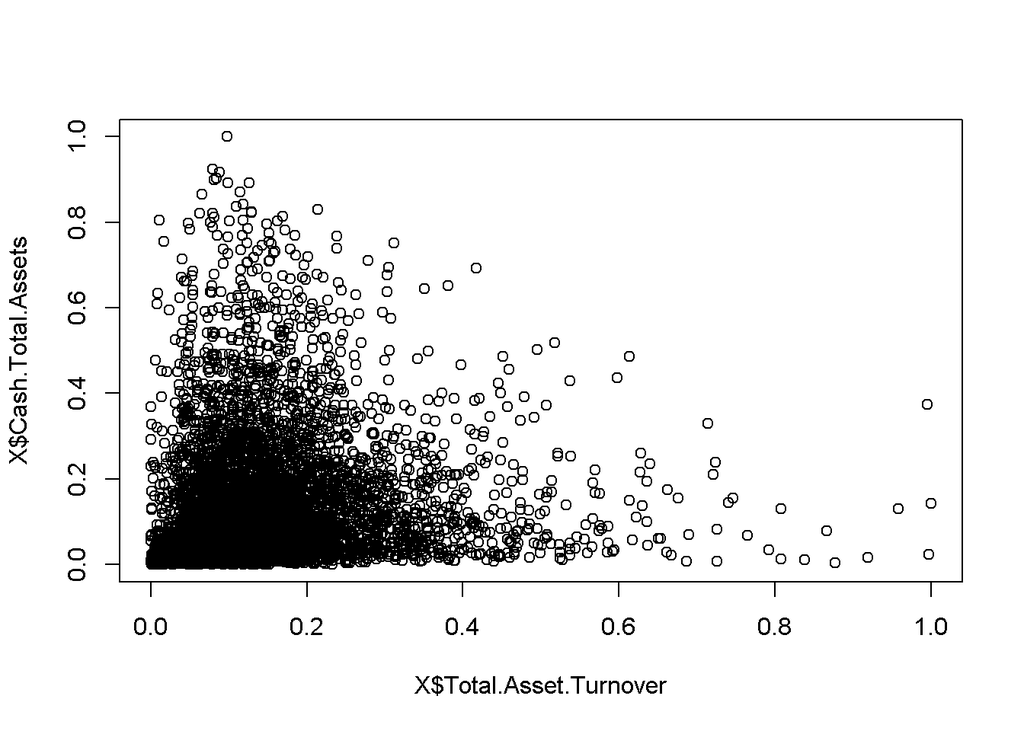

```r
plot(X$Total.Asset.Turnover, X$Cash.Total.Assets)
```

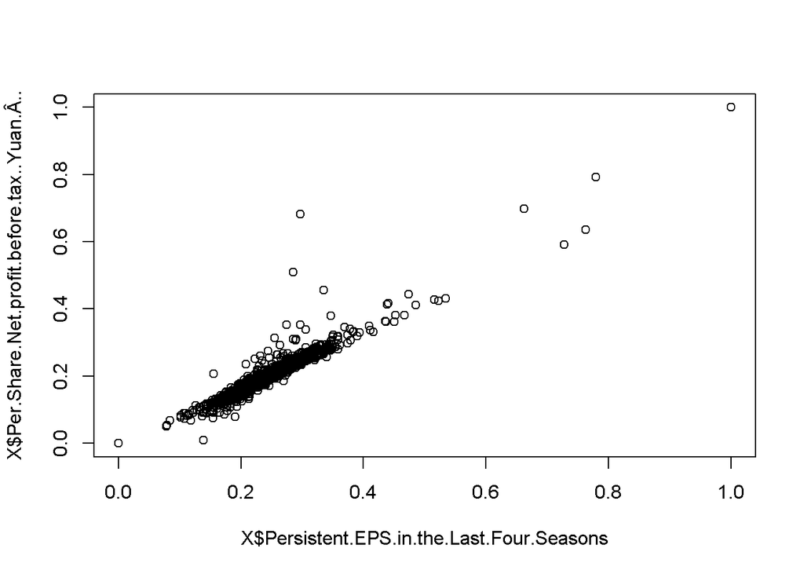

```r
plot(X$Persistent.EPS.in.the.Last.Four.Seasons, X$Per.Share.Net.profit.before.tax..Yuan.Â..) #EPS- Earnings per share
```

The second model is non-linear model called *intrinsically linear*. It is linear cause it can be transformed to straight line by a logarithmic transformation.

```r
df.copy<- df[df$Equity.to.Liability > 0.1,]
X.copy <- df.copy[-c(1)]
exponential.model <- lm(log(X.copy$Equity.to.Liability) ~ X.copy$Net.worth.Assets)
summary(exponential.model)
```

```
##
## Call:
## lm(formula = log(X.copy$Equity.to.Liability) ~ X.copy$Net.worth.Assets)
##
## Residuals:
##      Min       1Q   Median       3Q      Max
## -0.10343 -0.07906 -0.01923  0.05143  0.75107
##
## Coefficients:
##                         Estimate Std. Error t value Pr(>|t|)
## (Intercept)             -44.7212     0.5221  -85.65   <2e-16 ***
## X.copy$Net.worth.Assets  43.9701     0.5358   82.06   <2e-16 ***
## ---
## Signif. codes:  0 '***' 0.001 '**' 0.01 '*' 0.05 '.' 0.1 ' ' 1
##
## Residual standard error: 0.1102 on 491 degrees of freedom
## Multiple R-squared:  0.932,  Adjusted R-squared:  0.9319
## F-statistic:  6734 on 1 and 491 DF,  p-value: < 2.2e-16
```

```r
summary(lm(X.copy$Equity.to.Liability~X.copy$Net.worth.Assets))
```

```
##
## Call:
## lm(formula = X.copy$Equity.to.Liability ~ X.copy$Net.worth.Assets)
##
## Residuals:
##      Min       1Q   Median       3Q      Max
## -0.05665 -0.04194 -0.00629  0.02504  0.56953
##
## Coefficients:
##                         Estimate Std. Error t value Pr(>|t|)
## (Intercept)              -9.6734     0.3165  -30.57   <2e-16 ***
## X.copy$Net.worth.Assets  10.1039     0.3248   31.11   <2e-16 ***
## ---
## Signif. codes:  0 '***' 0.001 '**' 0.01 '*' 0.05 '.' 0.1 ' ' 1
##
## Residual standard error: 0.06677 on 491 degrees of freedom
## Multiple R-squared:  0.6634, Adjusted R-squared:  0.6627
## F-statistic: 967.8 on 1 and 491 DF,  p-value: < 2.2e-16
```

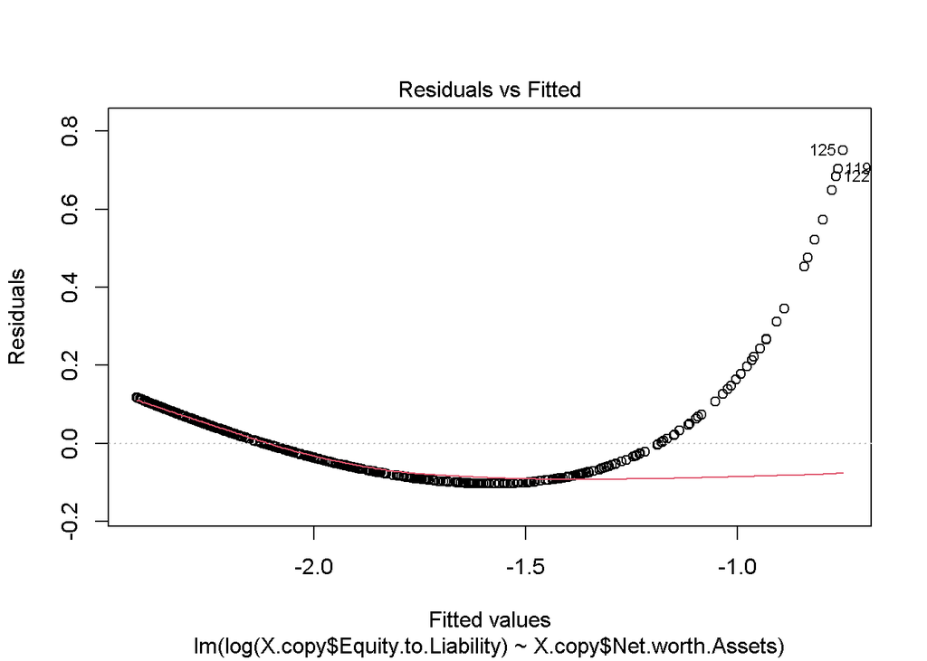

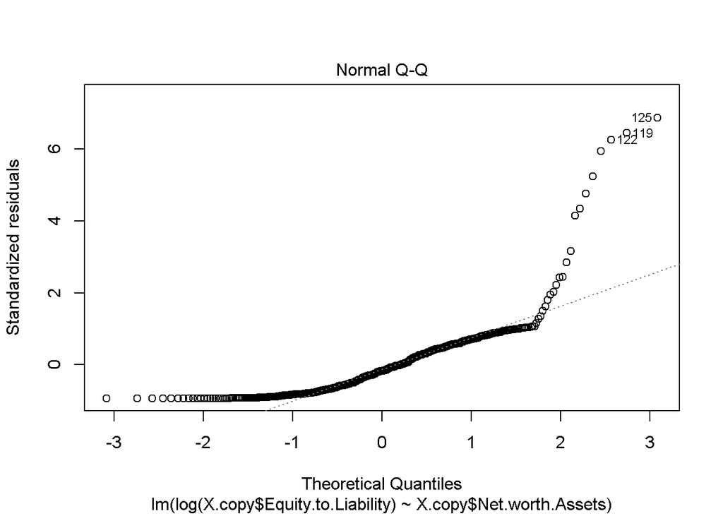

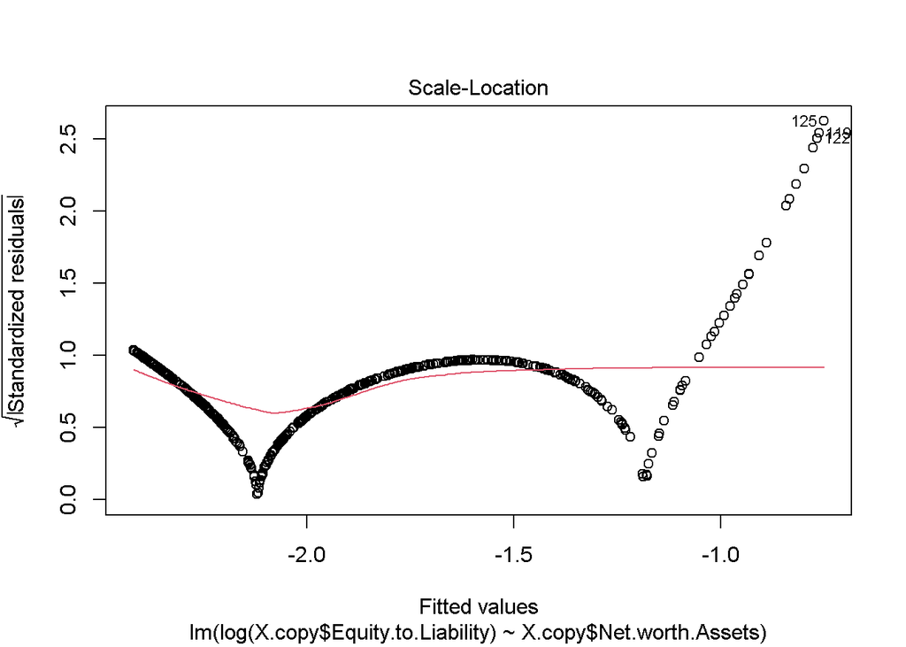

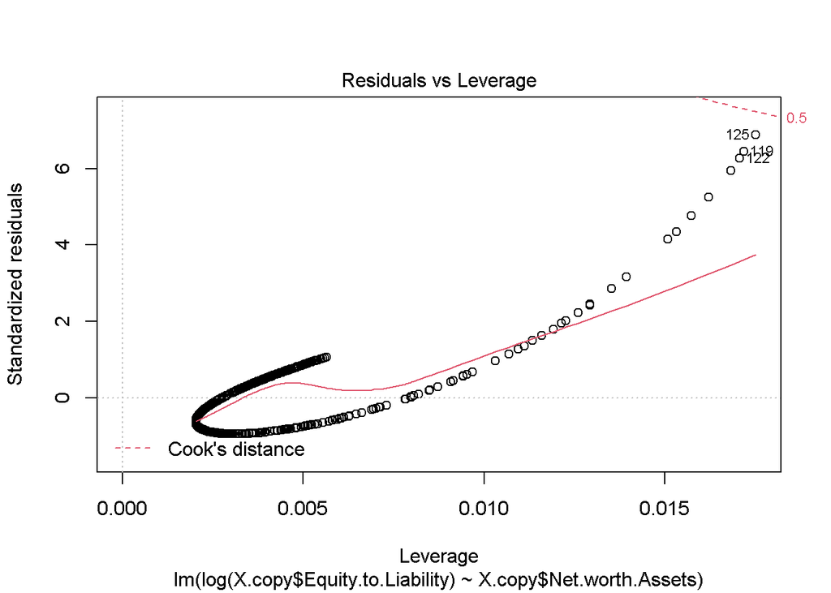

```r
plot(exponential.model)
```

```r
#The output was error cause there are x and y values that are not in domain of log-function.
# Reminder: remove the outlier where Y=0.0 that is showed in second scatter plot.
```

### Interpreting the intercept and the slope in a regression model

```r
fit<-lm(X$Persistent.EPS.in.the.Last.Four.Seasons~X$Per.Share.Net.profit.before.tax..Yuan.Â..)
summary(fit)
```

```
##
## Call:
## lm(formula = X$Persistent.EPS.in.the.Last.Four.Seasons ~ X$Per.Share.Net.profit.before.tax..Yuan.Â..)
##
## Residuals:
##      Min       1Q   Median       3Q      Max
## -0.40906 -0.00199 -0.00018  0.00229  0.10806
##
## Coefficients:
##                                              Estimate Std. Error t value
## (Intercept)                                 0.0522020  0.0006703   77.88
## X$Per.Share.Net.profit.before.tax..Yuan.Â.. 0.9579643  0.0035781  267.73
##                                             Pr(>|t|)
## (Intercept)                                   <2e-16 ***
## X$Per.Share.Net.profit.before.tax..Yuan.Â..   <2e-16 ***
## ---
## Signif. codes:  0 '***' 0.001 '**' 0.01 '*' 0.05 '.' 0.1 ' ' 1
##
## Residual standard error: 0.009803 on 6817 degrees of freedom
## Multiple R-squared:  0.9132, Adjusted R-squared:  0.9131
## F-statistic: 7.168e+04 on 1 and 6817 DF,  p-value: < 2.2e-16
```

There is no special interpreting on intercept. There will be if value of X is0, then intercept is expected value of Y.

### Residuals

```r
y<- X$Per.Share.Net.profit.before.tax..Yuan.Â..
x<- X$Persistent.EPS.in.the.Last.Four.Seasons
fit2<-lm(y~x)
# With implemented method
e<- resid(fit2)
#Now we're going to obtain the residuals manually, firs we need to get Ys by predicting
yhat<-predict(fit2)
#Residuals are defined by y-yhat
#Let's check by comparing this with R's build in resid function
max(abs(e-(y-yhat)))
```

```
## [1] 1.513546e-15
```

```r
#Now, with hard coding the calculation of yhat
max(abs(e-(y- coef(fit2)[1]-coef(fit2)[2]*x)))
```

```
## [1] 1.513546e-15
```

### Residuals versus X

Using this plot, we can see the instances of poor model fit

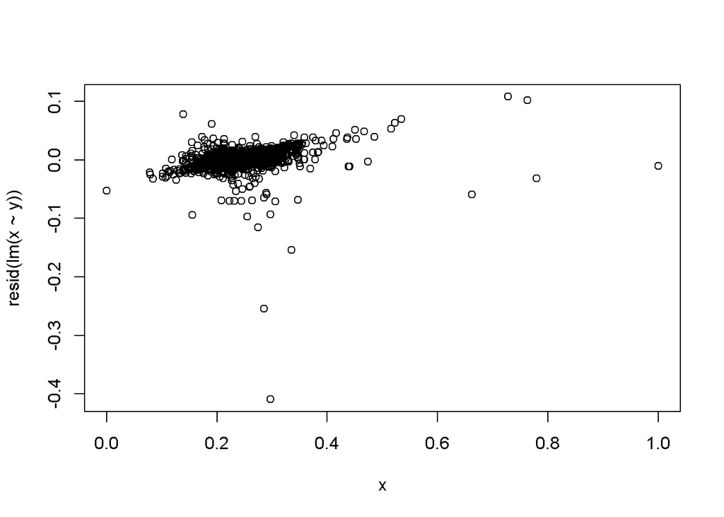

```r
plot(x, resid(lm(x~y)))
```

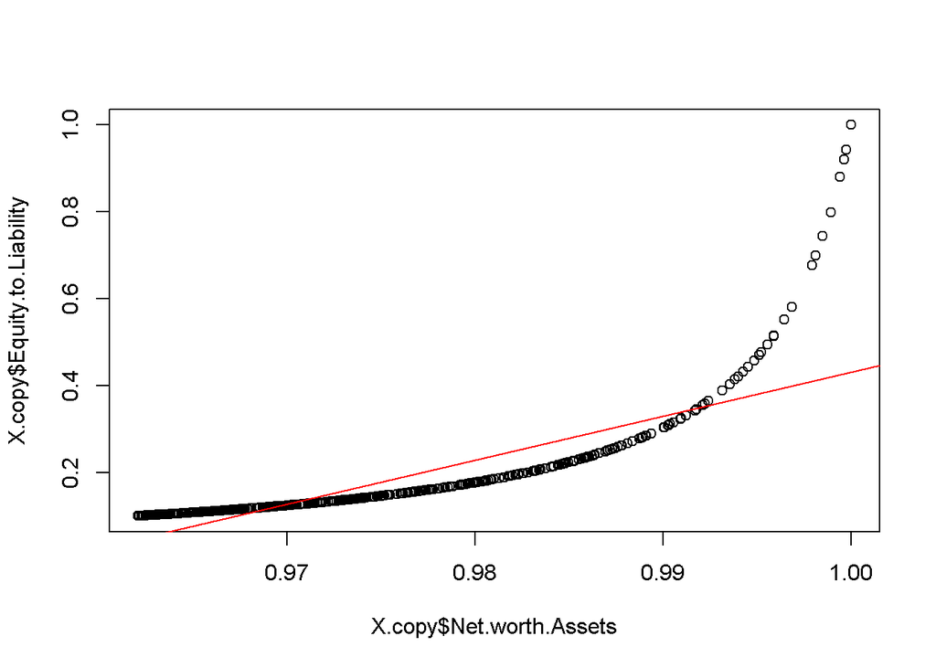

```r
plot(X.copy$Net.worth.Assets, X.copy$Equity.to.Liability) #nonlinear model
abline(lm(X.copy$Equity.to.Liability ~ X.copy$Net.worth.Assets ), col='red')
```

Here’s what happens when we focus on the residuals

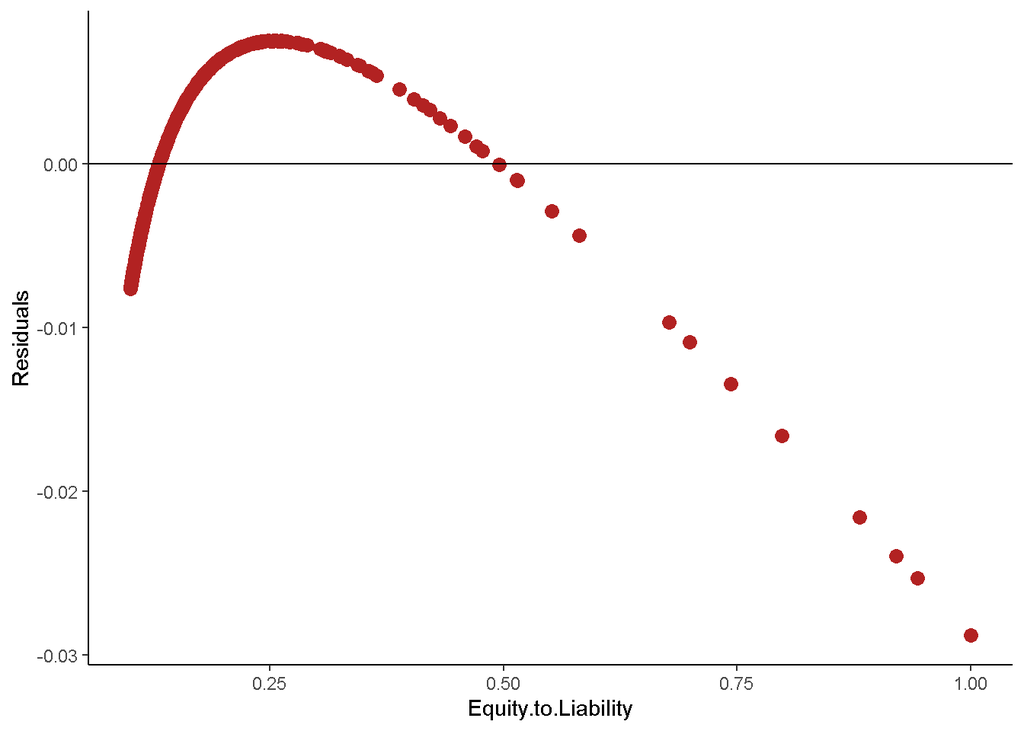

```r
y<- X.copy$Net.worth.Assets
x<- X.copy$Equity.to.Liability
library(ggplot2)
ggplot(X.copy, aes(Equity.to.Liability, resid(lm(y~x)))) +
    geom_point(size = 3, col = "firebrick") +
    geom_hline(yintercept=0, color = "black") +
    labs(x = "Equity.to.Liability", y = "Residuals") +
    theme_classic()
```

Estimating residual variation

```r
fit<-lm(y~x); n<-length(y)
#Comparing the estimate from lm comparing and  directly calculating from the residuals
summary(fit)$sigma == sqrt(sum(resid(fit)^2)/(n-2))
```

```
## [1] TRUE
```

### Summarizing variation

```r
y<- X$Per.Share.Net.profit.before.tax..Yuan.Â..
x<- X$Persistent.EPS.in.the.Last.Four.Seasons
fit<-lm(y~x)
regress.var = sum((predict(fit)-mean(y))^2)
residual.var = sum((y-predict(fit))^2)
total.var= regress.var+residual.var
total.var
```

```
## [1] 7.506115
```

```r
#To check, derive from equation for R squared R^2 = regress.var / total.var6
regress.var/summary(fit)$r.squared
```

```
## [1] 7.506115
```

## Regression inference

```r
y<-X$Current.Liability.to.Assets; x<-X$Net.worth.Assets; n<-length(X$Net.worth.Assets)
beta1<- cor(y,x)*sd(y)/sd(x)
beta0<- mean(y)-beta1*mean(x)
e <- y - beta0 - beta1*x
sigma<- sqrt(sum(e^2)/(n-2))
ssx<- sum((x-mean(x))^2) #sum of squared deviations from the mean of X

#Calculate standard errors for the coefficients and t-statistic
#Null hypotheses are Ho : Bj=0
seBeta0<- (1 / n + mean(x) ^ 2 / ssx) ^ 0.5 * sigma
seBeta1<- sigma/sqrt(ssx)
tBeta0 <- beta0 / seBeta0
tBeta1 <- beta1 / seBeta1

#p-values
pBeta0 <- 2 * pt(abs(tBeta0), df = n-2, lower.tail = FALSE)
pBeta1 <- 2 * pt(abs(tBeta1), df = n-2, lower.tail = FALSE)
coefTable<-rbind(c(beta0,seBeta0,tBeta0,pBeta0), c(beta1, seBeta1, tBeta1, pBeta1))
colnames(coefTable)<- c("Estimates", "Std. Error", "t value", "P(>|t|)")
rownames(coefTable)<- c("(Intercept)","x")
coefTable
```

```
##              Estimates  Std. Error   t value P(>|t|)
## (Intercept)  0.7875843 0.005405163  145.7096       0
## x           -0.7858520 0.006083741 -129.1725       0
```

```r
#built-in methods
fit<-lm(y~x)
summary(fit)$coefficients
```

```
##               Estimate  Std. Error   t value Pr(>|t|)
## (Intercept)  0.7875843 0.005405163  145.7096        0
## x           -0.7858520 0.006083741 -129.1725        0
```

### Getting a confidence interval

Confidence interval for the intercept

```r
sumCoef<- summary(fit)$coefficients
sumCoef[1,1]+c(-1,1)*qt(0.95, df=fit$df)*sumCoef[1,2]
```

```
## [1] 0.7786924 0.7964763
```

Now, let’s do the slope:

```r
sumCoef[2,1]+c(-1,1)*qt(0.95, df=fit$df)*sumCoef[2,2]
```

```
## [1] -0.7958602 -0.7758438
```

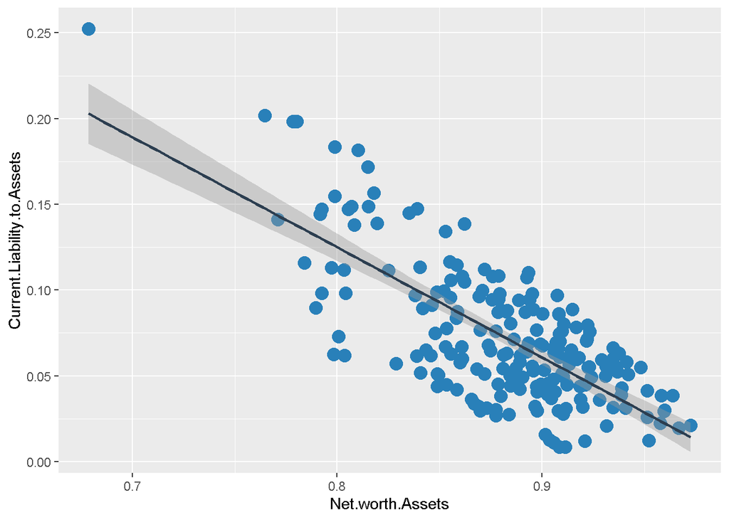

```r
library(ggplot2)
ggplot(df[1:200,], aes(x=Net.worth.Assets, y=Current.Liability.to.Assets)) +
  geom_point(color='#2980B9', size = 4) +
  geom_smooth(method=lm, color='#2C3E50')
```

```r
#The gray bands around the line represent the standard error of the regression line
```

## Multivariable regression analysis

```r
#Targer->compute beta1
x1<-X$Revenue.per.person
x2<-X$Working.Capital.Equity
x3<-X$Fixed.Assets.to.Assets
y<-X$Research.and.development.expense.rate
#Get the residuals having removed X2 and X3 from X1 and Y
ey<-resid(lm(y ~ x2 + x3))
ex1<-resid(lm(x1 ~ x2 + x3))
#Fit regression through the origin with the residuals
sum(ey * ex1)/sum(ex1 ^ 2)
```

```
## [1] -0.2409445
```

```r
#Check with built-in method lm
coef(lm(ey ~ ex1 - 1))
```

```
##        ex1
## -0.2409445
```

```r
#Fit the full linear model to show that it agrees
coef(lm(y~x1+x2+x3))
```

```
##   (Intercept)            x1            x2            x3
##  1.018728e+09 -2.409445e-01  1.267364e+09 -2.355848e-01
```

```r
#Examples with more features
data<- df[,c("Working.Capital.to.Total.Assets","Quick.Assets.Total.Assets","Current.Assets.Total.Assets","Cash.Flow.to.Sales","Working.capitcal.Turnover.Rate","Debt.ratio..","Net.worth.Assets")]
summary(lm(Working.Capital.to.Total.Assets ~ ., data=data))
```

```
##
## Call:
## lm(formula = Working.Capital.to.Total.Assets ~ ., data = data)
##
## Residuals:
##       Min        1Q    Median        3Q       Max
## -0.217784 -0.012794 -0.002309  0.010500  0.203718
##
## Coefficients: (1 not defined because of singularities)
##                                 Estimate Std. Error  t value Pr(>|t|)
## (Intercept)                     0.730968   0.017542   41.669   <2e-16 ***
## Quick.Assets.Total.Assets       0.004094   0.001900    2.155   0.0312 *
## Current.Assets.Total.Assets     0.208857   0.001764  118.381   <2e-16 ***
## Cash.Flow.to.Sales              0.031187   0.081945    0.381   0.7035
## Working.capitcal.Turnover.Rate  0.046080   0.085477    0.539   0.5898
## Debt.ratio..                   -0.670416   0.004698 -142.715   <2e-16 ***
## Net.worth.Assets                      NA         NA       NA       NA
## ---
## Signif. codes:  0 '***' 0.001 '**' 0.01 '*' 0.05 '.' 0.1 ' ' 1
##
## Residual standard error: 0.02006 on 6813 degrees of freedom
## Multiple R-squared:  0.8847, Adjusted R-squared:  0.8846
## F-statistic: 1.046e+04 on 5 and 6813 DF,  p-value: < 2.2e-16
```

```r
summary(lm(Quick.Assets.Total.Assets ~ . - Net.worth.Assets, data=data))
```

```
##
## Call:
## lm(formula = Quick.Assets.Total.Assets ~ . - Net.worth.Assets,
##     data = data)
##
## Residuals:
##      Min       1Q   Median       3Q      Max
## -0.69220 -0.04342  0.01242  0.06900  0.73438
##
## Coefficients:
##                                 Estimate Std. Error t value Pr(>|t|)
## (Intercept)                     -0.01384    0.12526  -0.110   0.9120
## Working.Capital.to.Total.Assets  0.16634    0.07720   2.155   0.0312 *
## Current.Assets.Total.Assets      0.68185    0.01784  38.215   <2e-16 ***
## Cash.Flow.to.Sales               1.14475    0.52214   2.192   0.0284 *
## Working.capitcal.Turnover.Rate  -1.32452    0.54460  -2.432   0.0150 *
## Debt.ratio..                    -0.52589    0.05947  -8.843   <2e-16 ***
## ---
## Signif. codes:  0 '***' 0.001 '**' 0.01 '*' 0.05 '.' 0.1 ' ' 1
##
## Residual standard error: 0.1279 on 6813 degrees of freedom
## Multiple R-squared:  0.5997, Adjusted R-squared:  0.5994
## F-statistic:  2041 on 5 and 6813 DF,  p-value: < 2.2e-16
```

## Dummy variables

```r
library(dplyr)
```

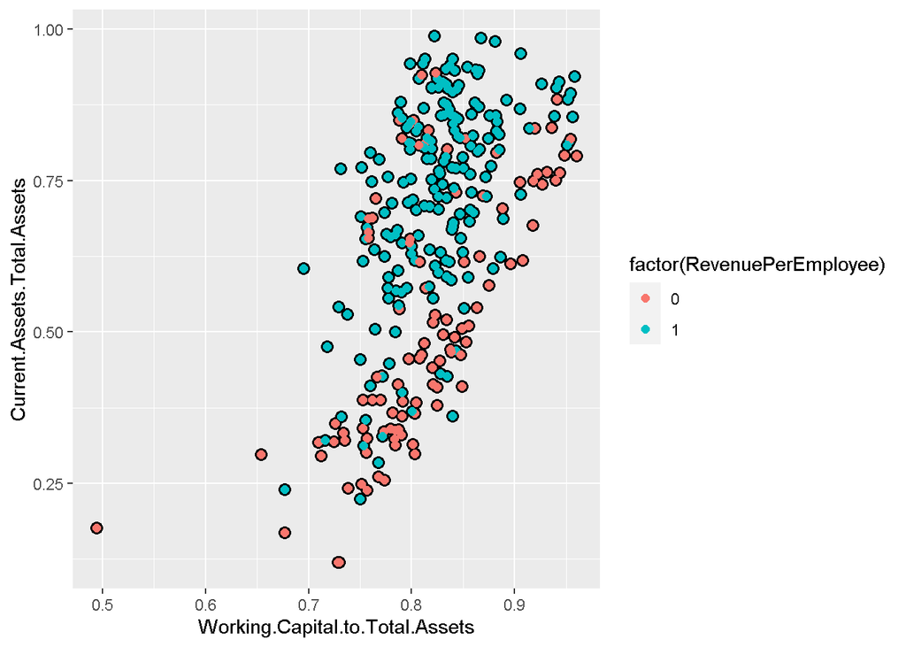

```r
data = mutate(data, RevenuePerEmployee = 1 * (X$Revenue.per.person > 0.018))
library(ggplot2)
g = ggplot(data[1900:2200,], aes(x=Working.Capital.to.Total.Assets, y=Current.Assets.Total.Assets, color=factor(RevenuePerEmployee)))
g = g + geom_point(size=3, colour = "black") + geom_point(size=2)
g
```

```r
summary(lm(Current.Assets.Total.Assets ~ Working.Capital.to.Total.Assets * factor(RevenuePerEmployee),data=data))$coef
```

```
##                                                               Estimate
## (Intercept)                                                 -1.4812570
## Working.Capital.to.Total.Assets                              2.3993996
## factor(RevenuePerEmployee)1                                 -0.1387969
## Working.Capital.to.Total.Assets:factor(RevenuePerEmployee)1  0.2873959
##                                                             Std. Error
## (Intercept)                                                 0.03342349
## Working.Capital.to.Total.Assets                             0.04133797
## factor(RevenuePerEmployee)1                                 0.04896695
## Working.Capital.to.Total.Assets:factor(RevenuePerEmployee)1 0.05997821
##                                                                t value
## (Intercept)                                                 -44.317838
## Working.Capital.to.Total.Assets                              58.043477
## factor(RevenuePerEmployee)1                                  -2.834502
## Working.Capital.to.Total.Assets:factor(RevenuePerEmployee)1   4.791672
##                                                                 Pr(>|t|)
## (Intercept)                                                 0.000000e+00
## Working.Capital.to.Total.Assets                             0.000000e+00
## factor(RevenuePerEmployee)1                                 4.603219e-03
## Working.Capital.to.Total.Assets:factor(RevenuePerEmployee)1 1.688987e-06
```

```r
#The interaction term is the estimate change in the slope.
```

## Residuals, variation, diagnostic

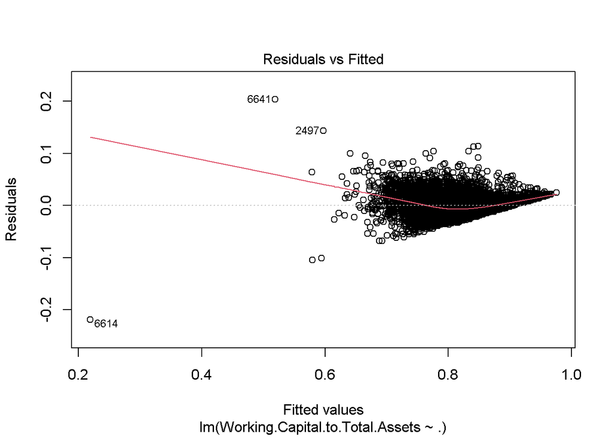

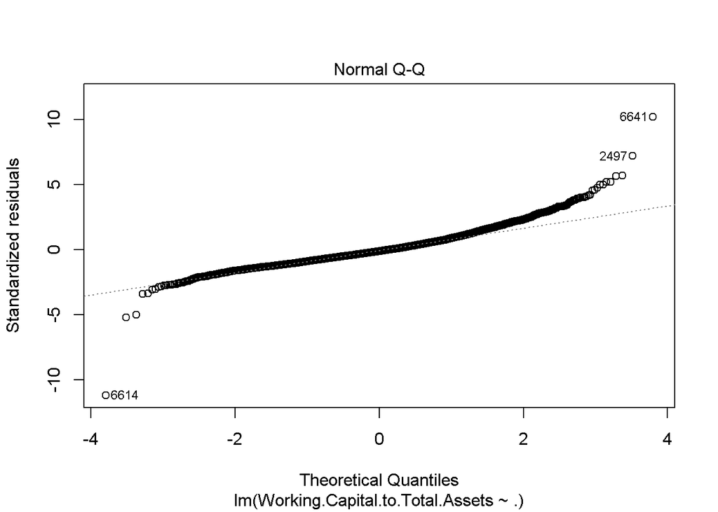

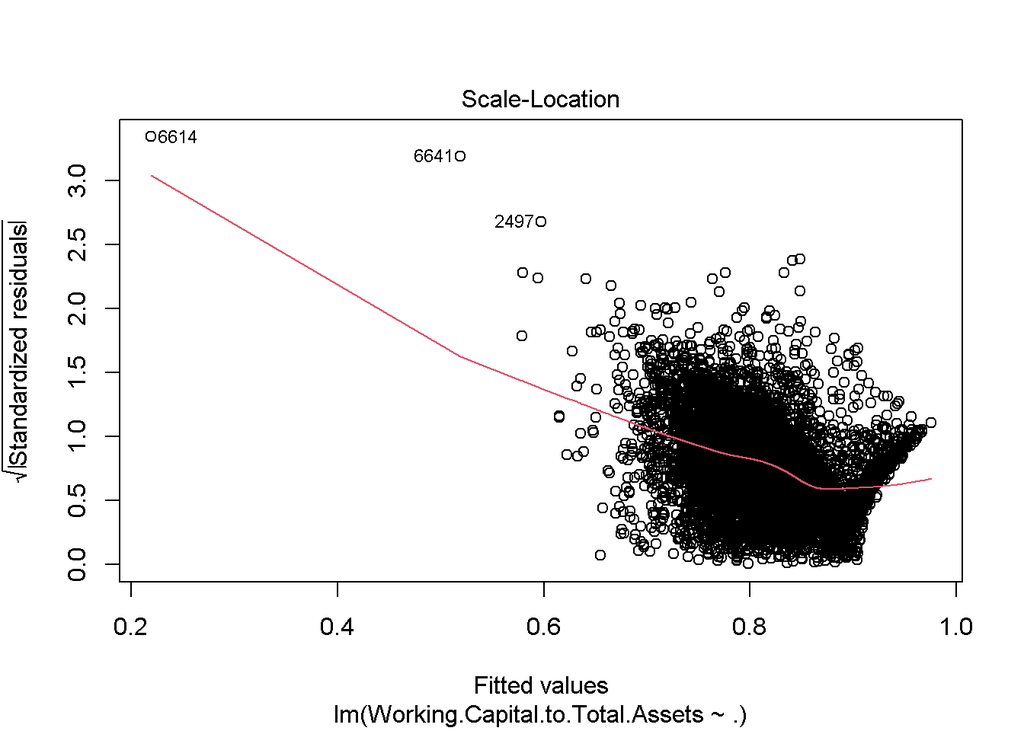

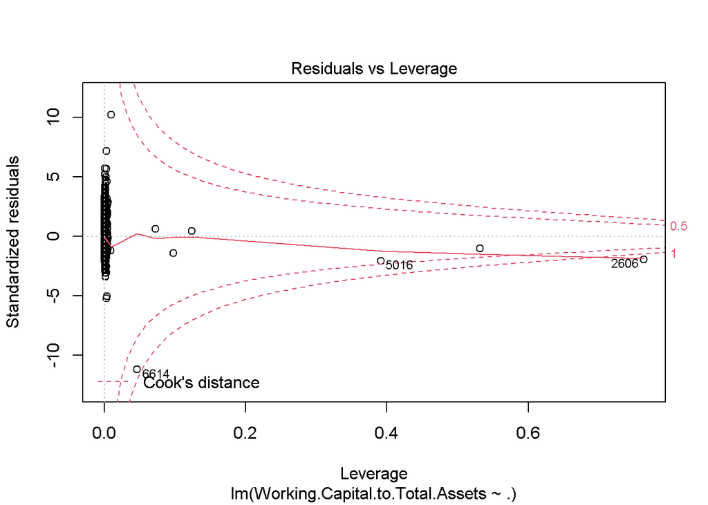

```r
plot(lm(Working.Capital.to.Total.Assets ~ ., data=data))
```

### Outliers, Leverage, Influence

```r
fit<-lm(Working.Capital.to.Total.Assets ~ Net.worth.Assets, data=data)
round(dfbetas(fit)[1:10,2],3) #change in individual coefficients when i-th point is deleted in fitting model
```

```
##      1      2      3      4      5      6      7      8      9     10
##  0.037  0.008 -0.030  0.011 -0.002  0.027  0.012  0.000 -0.008 -0.001
```

```r
round(hatvalues(fit)[1:10],3)# change in the predicted response when i-th point is deleted in fitting the model
```

```
##     1     2     3     4     5     6     7     8     9    10
## 0.001 0.000 0.001 0.000 0.000 0.000 0.001 0.000 0.000 0.000
```

## Variance Inflation Factor

```r
library(car)
fit<-lm(Working.Capital.to.Total.Assets ~ . - Net.worth.Assets, data=data)
vif(fit)
```

```
##      Quick.Assets.Total.Assets    Current.Assets.Total.Assets
##                       2.500197                       2.638513
##             Cash.Flow.to.Sales Working.capitcal.Turnover.Rate
##                       9.935424                       9.944658
##                   Debt.ratio..             RevenuePerEmployee
##                       1.104779                       1.129399
```

```r
# measure of the amount of multicollinearity in a set of multiple regression variables
```

## Principal Component Analysis

```r
companies.pca<-prcomp(df[, c(30:35)],center = TRUE, scale. = TRUE)
summary(companies.pca)
```

```
## Importance of components:
##                           PC1    PC2    PC3    PC4    PC5    PC6
## Standard deviation     1.0473 1.0021 1.0004 0.9997 0.9820 0.9666
## Proportion of Variance 0.1828 0.1674 0.1668 0.1666 0.1607 0.1557
## Cumulative Proportion  0.1828 0.3502 0.5170 0.6835 0.8443 1.0000
```

```r
library(devtools)
```

```r
install_github("vqv/ggbiplot")
```

```
## WARNING: Rtools is required to build R packages, but is not currently installed.
##
## Please download and install Rtools 4.0 from https://cran.r-project.org/bin/windows/Rtools/.
```

```
## Skipping install of 'ggbiplot' from a github remote, the SHA1 (7325e880) has not changed since last install.
##   Use `force = TRUE` to force installation
```

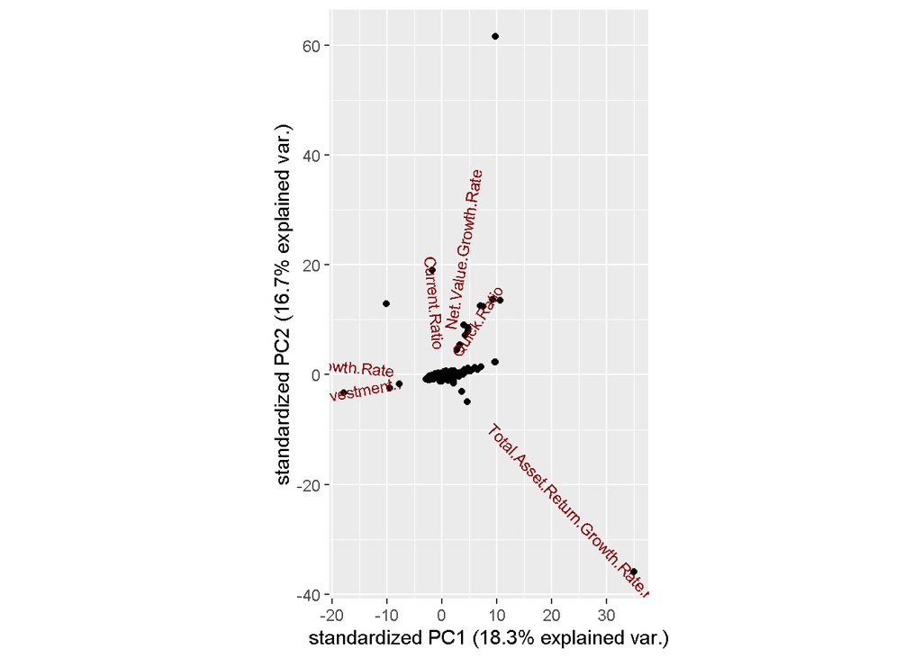

```r
library(ggbiplot)
ggbiplot(companies.pca)
```

```r
glm.fit<-glm(df$Bankrupt~companies.pca$x)
summary(glm.fit)
```

```
##
## Call:
## glm(formula = df$Bankrupt ~ companies.pca$x)
##
## Deviance Residuals:
##      Min        1Q    Median        3Q       Max
## -0.22084  -0.03519  -0.02951  -0.02541   1.22224
##
## Coefficients:
##                      Estimate Std. Error t value Pr(>|t|)
## (Intercept)         0.0322628  0.0021308  15.141  < 2e-16 ***
## companies.pca$xPC1  0.0104281  0.0020347   5.125 3.05e-07 ***
## companies.pca$xPC2  0.0122429  0.0021265   5.757 8.92e-09 ***
## companies.pca$xPC3 -0.0037867  0.0021300  -1.778   0.0755 .
## companies.pca$xPC4 -0.0010953  0.0021315  -0.514   0.6074
## companies.pca$xPC5 -0.0029914  0.0021700  -1.378   0.1681
## companies.pca$xPC6 -0.0001669  0.0022045  -0.076   0.9397
## ---
## Signif. codes:  0 '***' 0.001 '**' 0.01 '*' 0.05 '.' 0.1 ' ' 1
##
## (Dispersion parameter for gaussian family taken to be 0.03095974)
##
##     Null deviance: 212.9  on 6818  degrees of freedom
## Residual deviance: 210.9  on 6812  degrees of freedom
## AIC: -4336
##
## Number of Fisher Scoring iterations: 2
```

The residual deviance shows how well the response is predicted by the model when the predictors are included.

## Poisson regression

```r
covid19<-read.csv("C:/Users/angel/Downloads/data (1).csv")
summary(fit<-glm(abs(deaths) ~ cases, family="poisson", data=covid19[covid19$geoId=="AT",]))
```

```
##
## Call:
## glm(formula = abs(deaths) ~ cases, family = "poisson", data = covid19[covid19$geoId ==
##     "AT", ])
##
## Deviance Residuals:
##     Min       1Q   Median       3Q      Max
## -3.7674  -1.3685  -0.3123   1.2492   4.4675
##
## Coefficients:
##              Estimate Std. Error z value Pr(>|z|)
## (Intercept) 3.208e+00  2.682e-02   119.6   <2e-16 ***
## cases       1.278e-05  6.352e-08   201.2   <2e-16 ***
## ---
## Signif. codes:  0 '***' 0.001 '**' 0.01 '*' 0.05 '.' 0.1 ' ' 1
##
## (Dispersion parameter for poisson family taken to be 1)
##
##     Null deviance: 59877.77  on 55  degrees of freedom
## Residual deviance:   159.13  on 54  degrees of freedom
## AIC: 450.54
##
## Number of Fisher Scoring iterations: 4
```

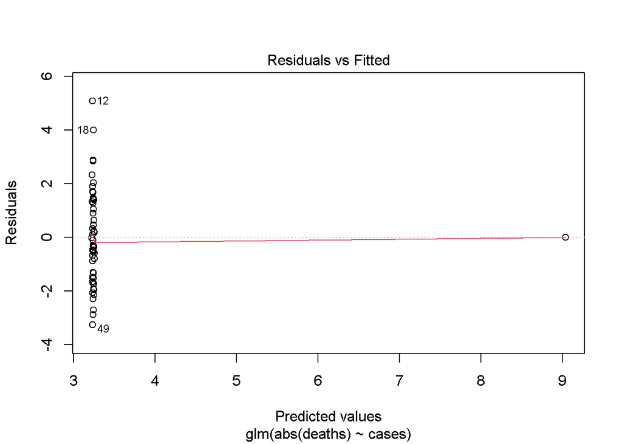

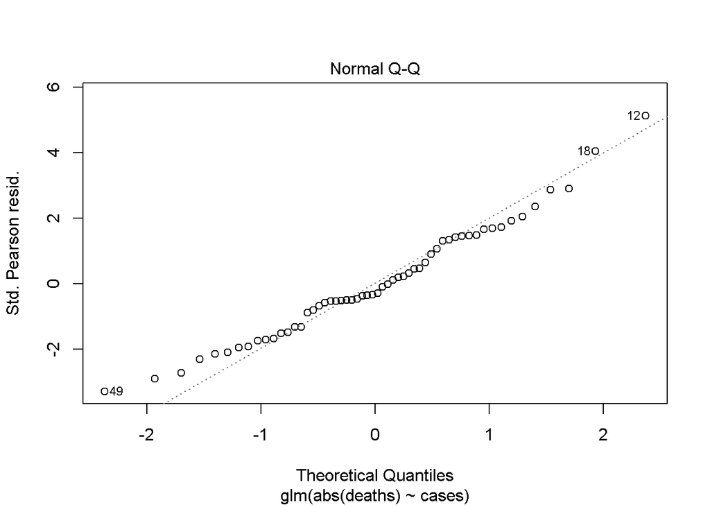

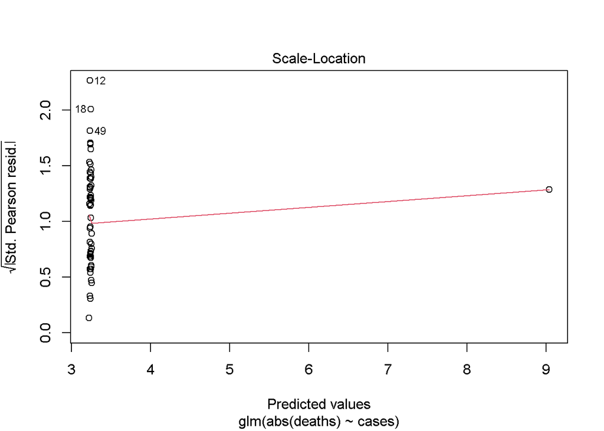

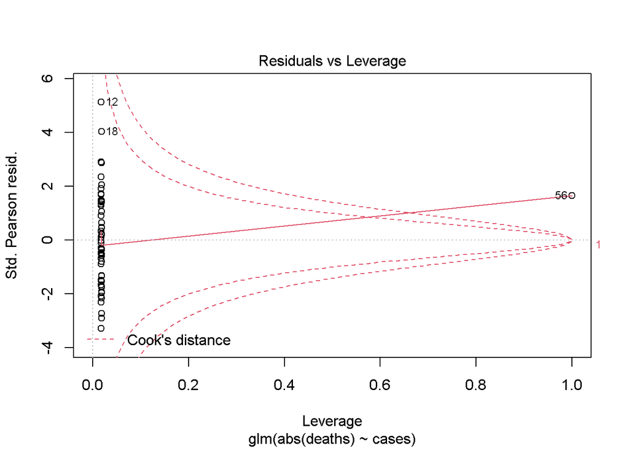

```r
plot(fit)
```

```r
#y- deaths , x - cases
```

## ANOVA One-way test

```r
dd <- data.frame(X,y=unlist(y))
summary(aov(dd$Net.worth.Assets~y,dd))
```

```
##               Df Sum Sq Mean Sq F value   Pr(>F)
## y              1   0.04 0.04043   13.93 0.000191 ***
## Residuals   6817  19.78 0.00290
## ---
## Signif. codes:  0 '***' 0.001 '**' 0.01 '*' 0.05 '.' 0.1 ' ' 1
```